# Bahadır Pamuk - Ekin Özgürbüz

# Team BUFAIM

### 03.01.2019

## Introduction

The problem is predicting the match outcomes on the English Premier League for 2019/2020 season. The data of the games played in the Premier League since 2010/2011 season and the odds given by different bookmakers is downloaded from the available dataset. The odds that are interested in are related with which side will win the game, 1x2 odds, and there are 3 odds for “Home win”, “Draw” and “Away win”. The forecasting is actually a supervised classification problem with three ordered levels. If a home team is winning, the match cannot end with the away team winning before becoming a “Tie”. Therefore, there is an ordinal relationship between classes.

There are two different sets of data available. The first of them is “matches”, which contains the past and upcoming match information. Home and away teams of a given match, the number of goals scored from each team and hence the match result and the date of matches can be found in this dataset. The second dataset is the “bets” data. In bets data, there is the odd information of various bookmakers for different matches and for all 3 odd types (Home win, away win and tie). This data stores odd information given by bookmakers on different dates.

## Related Literature

Football match predictions are very popular in research domain. Some of researches use the odd information supplied by the bookmakers, whereas the others uses in-match statistics such as shoot success rate, accurate passing rate, etc. There are many different prediction algorithms provided by researchers. For instance, Buursma D.[1] uses Bayesian network and logistic regression methods when predicting the Home, Draw, Away probabilities of matches from bookmakers’ odds and other available statistics. The paper concluded in a way that the accuracies were low but could be improved by adding more historical data. This project also had a drawback about missing data and small sample sizes of past matches between specific two teams.

## Approach

First of all, a crucial assumption about the lacking information is done. The assumption is that the bookmakers determine their odds based on many statistics and knowledge about the teams, players, weather. It is not possible to have information about these features. On the other hand, some observed information about players and teams which are not included in both dataset and odds are included in the predictions in addition to decisions coming from R models. The aim is to provide better predictions than the bookmakers at forecasting the match outcomes.

Evaluation of the predictions are done by a performance measure called Ranked Probability Score (RPS). RPS is a measure of how good the predictions with respect to actual results and probability distributions provided by the models. The primary measure of the project is average of 10 different matches in a week. Summation of all errors divided by number of matches creates the average. RPS captures the ordinal nature of the target as mentioned in the introduction section. Therefore, it is important to distribute the probabilities through classes. Further discussion on RPS and forecasting can be found in conclusion section.

Every team has different performance in home and away games. Therefore, any prediction model should include this perspective. However, odds information also contains home and away performances. As found in first homework, the matches between two relatively equal teams tend to end up with a tie result. In addition to the bias in tie matches, ordinal nature of the ranking probability score also increases the importance of tie outcomes and corresponding probability associated with them.

## Features

The features used for the model can be listed as league ID, total goals in a match, average goals scored in last 3 and 5 matches in both home and away games separately, average goals conceded in 3 and 5 games when playing in both home and away separately, average goals scored and conceded in all past games available, and average odd information of different bookmakers. Moreover, the classes that have constant probability to three different outcomes are added as a feature and a column in the complete data table. The corresponding initialization and preprocessing code can be seen in appendix and the related link on GitHub.

The goals that are conceded and scored in half time also affect a team’s overall performance. Therefore, 3,5 and n-lagged half time results are also taken into account. The teams score more half time goals would win the home games due to aura effect. Extra time goals are also added as features, however they don’t have any significant effect on splits since they mostly represent outlier matches. Football is a game about scoring and conceding goals, therefore this project mainly focused on capability of scoring and conceding goals of each team. Home and away characteristics of every team is also taken into account.

This project mainly focused on results of a tree constructed with respect to difference between home goals and away goals. There are 11 classes with respect to differences (i.e. -5 -4 -3 -2 -1 0 1 2 3 4 5). Each class has a constant probability with respect to a ratio calculated by real observations divided by number of instances in it. For instance, if “Class i” has 50 instances and 45 of them resulted with home win, probability of home win that will be submitted is 45/50 = 0.9. Sum of all three possible option probabilities equals to one, by definition. Different approaches such as penalized lasso regression, support vector machines and regression are tried through the time horizon of the project. However, the final model is a decision tree based on goal differences. The corresponding classes are added as a feature to each match.

## Results

First important remark about the resulting process is the property of RPS measure. For instance, in a case assigning binary probability to a match (i.e. 1 0 0) is compared with (0.92 0.08 0). Assume that the match ended up with a tie result. First error coming from binary assignment is 1, whereas second assignment resulted with an error 0.8464. Therefore, it can easily be concluded that giving some probability to “surprise” outcomes will result in better scores. Different parameters of the tree provided are examined by a for loop. RPS value for every trial is calculated in test data. 400 different combination of parameter set with respect to 20 different values for “minsplit” parameter and 20 different values for “cp” parameter is evaluated. Then, the parameter combination that has minimum RPS value is used for predictions.

#### Important Remark: These values should be halved, due to our calculation procedure is different from what is suggested by the instructor.

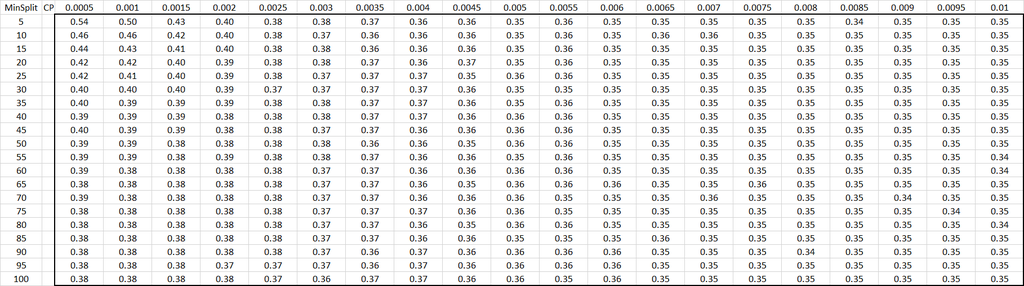

Calculated RPS Values.

Then more settings for the tree like max depth is looked into. The final Tree is seen as follows:

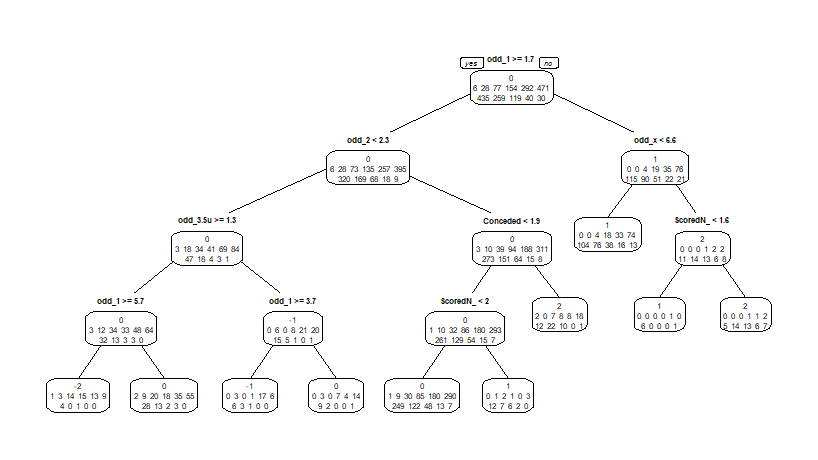

Final Tree.

The calculated probabilities for the matches is given below. Note that not all 80 matches can be given probability since our tree assumes certain odds be available in order to calculate. We can not calculate overall RPS since not all matches are finished yet.

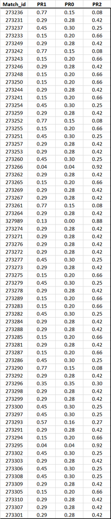

Match Probabilities.

## Conclusions and Future Work

Class imbalance problem should be handled. Possible techniques can be undersampling or oversampling the respective classes. Some tree parameters should be searched deeply, such as tree depth. Post pruning can be used for determining the depth of tree. Gradient boosted version of the tree approach can be used, since there are limited available data.

All matches played during the time horizon of the project is either watched completely or analyzed via examining the endgame statistics. It is observed that matches between relatively equal teams tend to end up with biased outcomes with respect to both our model and probabilities associated with odds given by bookmakers. As can be seen from the leaderboard sheet, some groups that did not predict and assigned with 0.33 probability to each class seem to perform better results. It is more likely to obtain better performance score with giving relatively equal probabilities to matches that can end up with a “surprise”. If each match is assigned with binary probability rather than continuous option, one should come up with nearly 8 correct predictions out of 10 matches in order to beat an arbitrary bookmaker. Therefore, if performance measure RPS is changed, binary challenge would end up with completely different strategies and leadership table. This project and the models are strongly influenced by RPS.

Lastly, all models and approaches that are done within the scope of this project are just “follower” models, since they just “follow” some assumptions and interpretations of bookmakers. If the data provided can be expanded, different complex and advanced models can be conducted in this manner. Head coach changes, “aura” effect on big matches, previous Champions League and other related matches starting elevens, even a footballer’s relations with his wife or head coach can be given as examples. Thus, we have submitted our probabilities not only depending on the model, but also our observations and data available on internet. To sum up, this project does not only include a modeling and coding phase, but also an enormous effort on analyses and time spent by watching the games or highlights.

## References

[1] Buursma D., “Predicting sports events from past results towards effective betting on football matches”, Conference paper, presented at 14th Twente Student Conference on IT, Twente, Holland, 21 January 2011

## Appendix

Here you can find the corresponding R-Script of the project

https://github.com/BU-IE-582/fall19-bahadirpamuk/blob/master/RScr%C3%ACpt.R